# Assignment 9. Data visualization

11/11/2020

```r
library(tidyverse)
library(lubridate)
library(legislatoR)
library(RColorBrewer)
library(waffle)
library(ggthemes)
library(legislatoR)
library(dplyr)
library(forcats)
library(ggplot2)
library(hrbrthemes)
library(jtools)
library(stargazer)
library(ggstance)
```

## 1. Fetching data on members of the 115th United States Congress

The `legislatoR` package (https://github.com/saschagobel/legislatoR) provides access to the Comparative Legislators Database (CLD). The CLD includes political, sociodemographic, career, online presence, public attention, and visual information (organized in separate tables, very similar to a proper database structure) for over 45,000 contemporary and historical politicians from ten countries.

Install the package (either from CRAN or GitHub) and use it to compile the following data into one dataset:

1. The political data for the 115th session of the US House of Representatives
2. The data on daily user traffic on individual Wikipedia biographies (use it to compute the average number of daily page views per representative between January 3, 2017 and January 3, 2019 and match the variable to the dataset)
3. The information on the total number of sessions served by representative (compute it by counting the number of entries in the political table when grouped by representative).

```r
# YOUR CODE HERE


# a)

# Get core data
US_House <- get_core(legislature = "usa_house")

# Get political data
US_Sessions <- get_political(legislature = "usa_house")

# Filter for the 115th session
US_115 <- US_Sessions %>% filter(session == 115)




# b)

# Get wikipedia traffic data
US_traffic <- get_traffic(legislature = "usa_house")

# Filter for time frame and calculate average number of daily page views
US_daily <- US_traffic %>%
  filter(date >= "2017-01-03" & date <= "2019-01-03") %>%
  select(!date) %>%
  group_by(pageid) %>%
  dplyr::summarize(Mean_DailyPageView = mean(traffic, na.rm=TRUE))
# c)

US_Sessions_total <-  US_Sessions %>% group_by(pageid) %>% dplyr::summarize(Total_Sessions = n())
# Alternatively:
#US_Sessions_total <-  US_Sessions %>% count(pageid) %>% rename(Total_Sessions = n)



# Finally, compiling all into one dataset:

Merged_Dataset <-  US_Sessions_total %>%
  inner_join(US_daily, by = NULL) %>%
  inner_join(US_115, by = NULL)
```

## 2. Exploring the dataset

Explore the dataset using visual means, following the guidelines of good visualization. Provide three different visualizations. One visualization is entirely up to you. The two others should give any two of the following:

1. gender or ethnicity distribution by party (Democrat/Republican; ignore the others)
2. age distribution by state in which the representative’s district is located (limit to states with 10+ representatives)
3. top 10 representatives according to average daily page views
4. log mean page views vs. the number of sessions served

Transform the variables if needed (e.g., categorize continuous variables, pool residual categories into one, etc.).

```r
#a) ethnicity distribution by party (Democrat/Republican)

# Include gender, age, ethnicity data into the dataset
Merged_Dataset_Big <-  Merged_Dataset %>% inner_join(US_House, by = NULL)
```

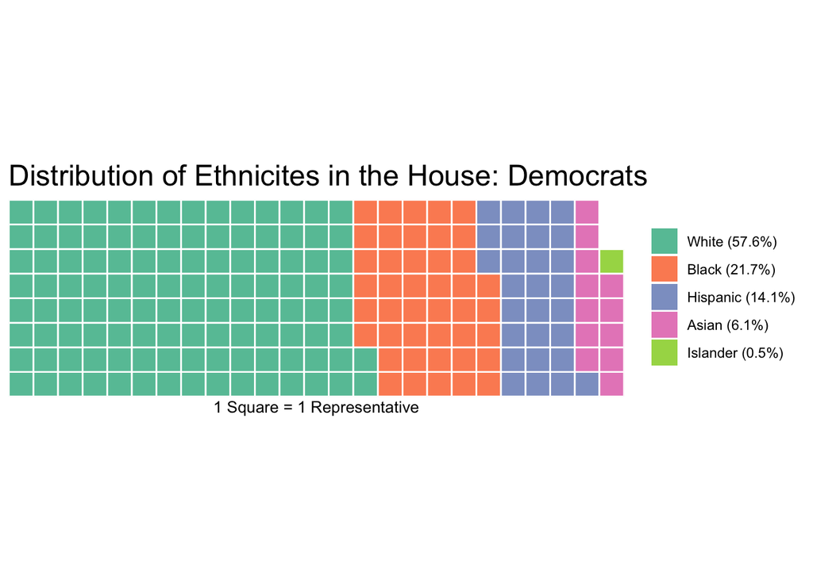

```r
# Democrats
# Filter for Party and count total number of representatives by ethnicity

Prop_Ethicity_D <-  Merged_Dataset_Big %>% filter(party == "D") %>%  count(ethnicity) %>% rename(Total = n) %>% arrange(-Total)
Labels_D <- c("White", "Black","Hispanic", "Asian", "Islander")


# Drawing a Waffle-Chart

val_names <- sprintf("%s (%s)", Labels_D, scales::percent(round(Prop_Ethicity_D$Total/sum(Prop_Ethicity_D$Total), 5)))
names(Prop_Ethicity_D$Total) <- val_names

waffle::waffle(Prop_Ethicity_D$Total, rows=8, size=0.5,
       title="Distribution of Ethnicites in the House: Democrats",
      xlab="1 Square = 1 Representative")
```

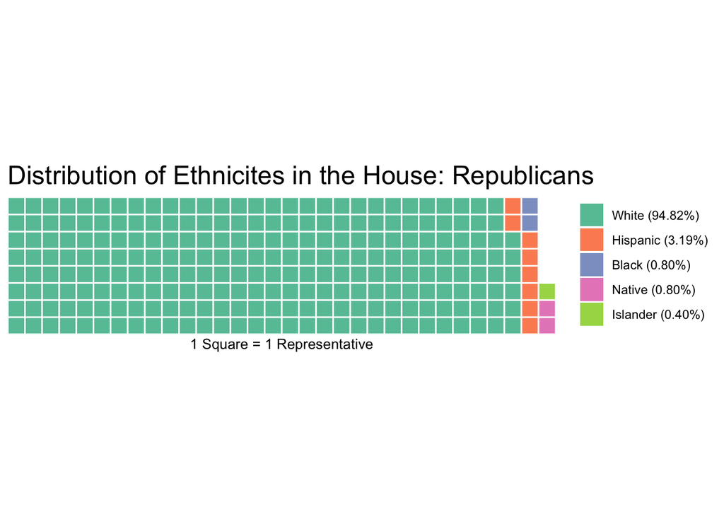

```r
# Republicans
# Filter for Party and count total number of representatives by ethnicity

Prop_Ethicity_R <-  Merged_Dataset_Big %>% filter(party == "R") %>%  count(ethnicity) %>% rename(Total = n) %>% arrange(-Total)
Labels_R <- c("White", "Hispanic", "Black", "Native", "Islander")

# Drawing a Waffle-Chart

val_names <- sprintf("%s (%s)", Labels_R, scales::percent(round(Prop_Ethicity_R$Total/sum(Prop_Ethicity_R$Total), 5)))
names(Prop_Ethicity_R$Total) <- val_names

waffle::waffle(Prop_Ethicity_R$Total, rows=8, size=0.5,
       title ="Distribution of Ethnicites in the House: Republicans",
      xlab="1 Square = 1 Representative")
```